# Cognifyz_Task_Level_1

## **Step 1: Import necessary Python libraries.**

```python
import pandas as pd
import numpy as np
import matplotlib.pyplot as plt
import seaborn as sns
```

## **Step 2: Load the dataset into a DataFrame.**

```python
# Read the csv file using pandas read_csv
restaurent_df = pd.read_csv(r"Dataset .csv")
restaurent_df
```

|  | Restaurant ID | Restaurant Name | Country Code | City | Address | Locality | Locality Verbose | Longitude | Latitude | Cuisines | ... | Currency | Has Table booking | Has Online delivery | Is delivering now | Switch to order menu | Price range | Aggregate rating | Rating color | Rating text | Votes |
| --- | --- | --- | --- | --- | --- | --- | --- | --- | --- | --- | --- | --- | --- | --- | --- | --- | --- | --- | --- | --- | --- |
| 0 | 6317637 | Le Petit Souffle | 162 | Makati City | Third Floor, Century City Mall, Kalayaan Avenu... | Century City Mall, Poblacion, Makati City | Century City Mall, Poblacion, Makati City, Mak... | 121.027535 | 14.565443 | French, Japanese, Desserts | ... | Botswana Pula(P) | Yes | No | No | No | 3 | 4.8 | Dark Green | Excellent | 314 |
| 1 | 6304287 | Izakaya Kikufuji | 162 | Makati City | Little Tokyo, 2277 Chino Roces Avenue, Legaspi... | Little Tokyo, Legaspi Village, Makati City | Little Tokyo, Legaspi Village, Makati City, Ma... | 121.014101 | 14.553708 | Japanese | ... | Botswana Pula(P) | Yes | No | No | No | 3 | 4.5 | Dark Green | Excellent | 591 |
| 2 | 6300002 | Heat - Edsa Shangri-La | 162 | Mandaluyong City | Edsa Shangri-La, 1 Garden Way, Ortigas, Mandal... | Edsa Shangri-La, Ortigas, Mandaluyong City | Edsa Shangri-La, Ortigas, Mandaluyong City, Ma... | 121.056831 | 14.581404 | Seafood, Asian, Filipino, Indian | ... | Botswana Pula(P) | Yes | No | No | No | 4 | 4.4 | Green | Very Good | 270 |
| 3 | 6318506 | Ooma | 162 | Mandaluyong City | Third Floor, Mega Fashion Hall, SM Megamall, O... | SM Megamall, Ortigas, Mandaluyong City | SM Megamall, Ortigas, Mandaluyong City, Mandal... | 121.056475 | 14.585318 | Japanese, Sushi | ... | Botswana Pula(P) | No | No | No | No | 4 | 4.9 | Dark Green | Excellent | 365 |
| 4 | 6314302 | Sambo Kojin | 162 | Mandaluyong City | Third Floor, Mega Atrium, SM Megamall, Ortigas... | SM Megamall, Ortigas, Mandaluyong City | SM Megamall, Ortigas, Mandaluyong City, Mandal... | 121.057508 | 14.584450 | Japanese, Korean | ... | Botswana Pula(P) | Yes | No | No | No | 4 | 4.8 | Dark Green | Excellent | 229 |
| ... | ... | ... | ... | ... | ... | ... | ... | ... | ... | ... | ... | ... | ... | ... | ... | ... | ... | ... | ... | ... | ... |
| 9546 | 5915730 | Naml۱ Gurme | 208 | ��stanbul | Kemanke�� Karamustafa Pa��a Mahallesi, R۱ht۱m ... | Karak�_y | Karak�_y, ��stanbul | 28.977392 | 41.022793 | Turkish | ... | Turkish Lira(TL) | No | No | No | No | 3 | 4.1 | Green | Very Good | 788 |
| 9547 | 5908749 | Ceviz A��ac۱ | 208 | ��stanbul | Ko��uyolu Mahallesi, Muhittin ��st�_nda�� Cadd... | Ko��uyolu | Ko��uyolu, ��stanbul | 29.041297 | 41.009847 | World Cuisine, Patisserie, Cafe | ... | Turkish Lira(TL) | No | No | No | No | 3 | 4.2 | Green | Very Good | 1034 |
| 9548 | 5915807 | Huqqa | 208 | ��stanbul | Kuru�_e��me Mahallesi, Muallim Naci Caddesi, N... | Kuru�_e��me | Kuru�_e��me, ��stanbul | 29.034640 | 41.055817 | Italian, World Cuisine | ... | Turkish Lira(TL) | No | No | No | No | 4 | 3.7 | Yellow | Good | 661 |
| 9549 | 5916112 | A���k Kahve | 208 | ��stanbul | Kuru�_e��me Mahallesi, Muallim Naci Caddesi, N... | Kuru�_e��me | Kuru�_e��me, ��stanbul | 29.036019 | 41.057979 | Restaurant Cafe | ... | Turkish Lira(TL) | No | No | No | No | 4 | 4.0 | Green | Very Good | 901 |
| 9550 | 5927402 | Walter's Coffee Roastery | 208 | ��stanbul | Cafea��a Mahallesi, Bademalt۱ Sokak, No 21/B, ... | Moda | Moda, ��stanbul | 29.026016 | 40.984776 | Cafe | ... | Turkish Lira(TL) | No | No | No | No | 2 | 4.0 | Green | Very Good | 591 |

9551 rows × 21 columns

## **Step 3: Basic Inspection on given dataset**

- **Top 5 rows - using head**

```python
restaurent_df.head()
```

|  | Restaurant ID | Restaurant Name | Country Code | City | Address | Locality | Locality Verbose | Longitude | Latitude | Cuisines | ... | Currency | Has Table booking | Has Online delivery | Is delivering now | Switch to order menu | Price range | Aggregate rating | Rating color | Rating text | Votes |
| --- | --- | --- | --- | --- | --- | --- | --- | --- | --- | --- | --- | --- | --- | --- | --- | --- | --- | --- | --- | --- | --- |
| 0 | 6317637 | Le Petit Souffle | 162 | Makati City | Third Floor, Century City Mall, Kalayaan Avenu... | Century City Mall, Poblacion, Makati City | Century City Mall, Poblacion, Makati City, Mak... | 121.027535 | 14.565443 | French, Japanese, Desserts | ... | Botswana Pula(P) | Yes | No | No | No | 3 | 4.8 | Dark Green | Excellent | 314 |
| 1 | 6304287 | Izakaya Kikufuji | 162 | Makati City | Little Tokyo, 2277 Chino Roces Avenue, Legaspi... | Little Tokyo, Legaspi Village, Makati City | Little Tokyo, Legaspi Village, Makati City, Ma... | 121.014101 | 14.553708 | Japanese | ... | Botswana Pula(P) | Yes | No | No | No | 3 | 4.5 | Dark Green | Excellent | 591 |
| 2 | 6300002 | Heat - Edsa Shangri-La | 162 | Mandaluyong City | Edsa Shangri-La, 1 Garden Way, Ortigas, Mandal... | Edsa Shangri-La, Ortigas, Mandaluyong City | Edsa Shangri-La, Ortigas, Mandaluyong City, Ma... | 121.056831 | 14.581404 | Seafood, Asian, Filipino, Indian | ... | Botswana Pula(P) | Yes | No | No | No | 4 | 4.4 | Green | Very Good | 270 |
| 3 | 6318506 | Ooma | 162 | Mandaluyong City | Third Floor, Mega Fashion Hall, SM Megamall, O... | SM Megamall, Ortigas, Mandaluyong City | SM Megamall, Ortigas, Mandaluyong City, Mandal... | 121.056475 | 14.585318 | Japanese, Sushi | ... | Botswana Pula(P) | No | No | No | No | 4 | 4.9 | Dark Green | Excellent | 365 |
| 4 | 6314302 | Sambo Kojin | 162 | Mandaluyong City | Third Floor, Mega Atrium, SM Megamall, Ortigas... | SM Megamall, Ortigas, Mandaluyong City | SM Megamall, Ortigas, Mandaluyong City, Mandal... | 121.057508 | 14.584450 | Japanese, Korean | ... | Botswana Pula(P) | Yes | No | No | No | 4 | 4.8 | Dark Green | Excellent | 229 |

5 rows × 21 columns

- **bottom 5 rows using tail**

```python
restaurent_df.tail()
```

|  | Restaurant ID | Restaurant Name | Country Code | City | Address | Locality | Locality Verbose | Longitude | Latitude | Cuisines | ... | Currency | Has Table booking | Has Online delivery | Is delivering now | Switch to order menu | Price range | Aggregate rating | Rating color | Rating text | Votes |
| --- | --- | --- | --- | --- | --- | --- | --- | --- | --- | --- | --- | --- | --- | --- | --- | --- | --- | --- | --- | --- | --- |
| 9546 | 5915730 | Naml۱ Gurme | 208 | ��stanbul | Kemanke�� Karamustafa Pa��a Mahallesi, R۱ht۱m ... | Karak�_y | Karak�_y, ��stanbul | 28.977392 | 41.022793 | Turkish | ... | Turkish Lira(TL) | No | No | No | No | 3 | 4.1 | Green | Very Good | 788 |
| 9547 | 5908749 | Ceviz A��ac۱ | 208 | ��stanbul | Ko��uyolu Mahallesi, Muhittin ��st�_nda�� Cadd... | Ko��uyolu | Ko��uyolu, ��stanbul | 29.041297 | 41.009847 | World Cuisine, Patisserie, Cafe | ... | Turkish Lira(TL) | No | No | No | No | 3 | 4.2 | Green | Very Good | 1034 |
| 9548 | 5915807 | Huqqa | 208 | ��stanbul | Kuru�_e��me Mahallesi, Muallim Naci Caddesi, N... | Kuru�_e��me | Kuru�_e��me, ��stanbul | 29.034640 | 41.055817 | Italian, World Cuisine | ... | Turkish Lira(TL) | No | No | No | No | 4 | 3.7 | Yellow | Good | 661 |
| 9549 | 5916112 | A���k Kahve | 208 | ��stanbul | Kuru�_e��me Mahallesi, Muallim Naci Caddesi, N... | Kuru�_e��me | Kuru�_e��me, ��stanbul | 29.036019 | 41.057979 | Restaurant Cafe | ... | Turkish Lira(TL) | No | No | No | No | 4 | 4.0 | Green | Very Good | 901 |
| 9550 | 5927402 | Walter's Coffee Roastery | 208 | ��stanbul | Cafea��a Mahallesi, Bademalt۱ Sokak, No 21/B, ... | Moda | Moda, ��stanbul | 29.026016 | 40.984776 | Cafe | ... | Turkish Lira(TL) | No | No | No | No | 2 | 4.0 | Green | Very Good | 591 |

5 rows × 21 columns

- **Inspecting Column Names and Data Types**

```python
restaurent_df.info()
```

```
<class 'pandas.core.frame.DataFrame'>
RangeIndex: 9551 entries, 0 to 9550
Data columns (total 21 columns):
 #   Column                Non-Null Count  Dtype
---  ------                --------------  -----
 0   Restaurant ID         9551 non-null   int64
 1   Restaurant Name       9551 non-null   object
 2   Country Code          9551 non-null   int64
 3   City                  9551 non-null   object
 4   Address               9551 non-null   object
 5   Locality              9551 non-null   object
 6   Locality Verbose      9551 non-null   object
 7   Longitude             9551 non-null   float64
 8   Latitude              9551 non-null   float64
 9   Cuisines              9542 non-null   object
 10  Average Cost for two  9551 non-null   int64
 11  Currency              9551 non-null   object
 12  Has Table booking     9551 non-null   object
 13  Has Online delivery   9551 non-null   object
 14  Is delivering now     9551 non-null   object
 15  Switch to order menu  9551 non-null   object
 16  Price range           9551 non-null   int64
 17  Aggregate rating      9551 non-null   float64
 18  Rating color          9551 non-null   object
 19  Rating text           9551 non-null   object
 20  Votes                 9551 non-null   int64
dtypes: float64(3), int64(5), object(13)
memory usage: 1.5+ MB
```

- **Checking for Missing Values**

```python
restaurent_df.isnull().sum()
```

```
Restaurant ID           0
Restaurant Name         0
Country Code            0
City                    0
Address                 0
Locality                0
Locality Verbose        0
Longitude               0
Latitude                0
Cuisines                9
Average Cost for two    0
Currency                0
Has Table booking       0
Has Online delivery     0
Is delivering now       0
Switch to order menu    0
Price range             0
Aggregate rating        0
Rating color            0
Rating text             0
Votes                   0
dtype: int64
```

- **Basic Statistical Summary**

```python
restaurent_df.describe()
```

|  | Restaurant ID | Country Code | Longitude | Latitude | Average Cost for two | Price range | Aggregate rating | Votes |
| --- | --- | --- | --- | --- | --- | --- | --- | --- |
| count | 9.551000e+03 | 9551.000000 | 9551.000000 | 9551.000000 | 9551.000000 | 9551.000000 | 9551.000000 | 9551.000000 |
| mean | 9.051128e+06 | 18.365616 | 64.126574 | 25.854381 | 1199.210763 | 1.804837 | 2.666370 | 156.909748 |
| std | 8.791521e+06 | 56.750546 | 41.467058 | 11.007935 | 16121.183073 | 0.905609 | 1.516378 | 430.169145 |
| min | 5.300000e+01 | 1.000000 | -157.948486 | -41.330428 | 0.000000 | 1.000000 | 0.000000 | 0.000000 |
| 25% | 3.019625e+05 | 1.000000 | 77.081343 | 28.478713 | 250.000000 | 1.000000 | 2.500000 | 5.000000 |
| 50% | 6.004089e+06 | 1.000000 | 77.191964 | 28.570469 | 400.000000 | 2.000000 | 3.200000 | 31.000000 |
| 75% | 1.835229e+07 | 1.000000 | 77.282006 | 28.642758 | 700.000000 | 2.000000 | 3.700000 | 131.000000 |
| max | 1.850065e+07 | 216.000000 | 174.832089 | 55.976980 | 800000.000000 | 4.000000 | 4.900000 | 10934.000000 |

- **Checking Unique Values**

```python
restaurent_df.nunique()
```

```
Restaurant ID           9551
Restaurant Name         7446
Country Code              15
City                     141
Address                 8918
Locality                1208
Locality Verbose        1265
Longitude               8120
Latitude                8677
Cuisines                1825
Average Cost for two     140
Currency                  12
Has Table booking          2
Has Online delivery        2
Is delivering now          2
Switch to order menu       1
Price range                4
Aggregate rating          33
Rating color               6
Rating text                6
Votes                   1012
dtype: int64
```

- **Checking Shape**

```python
restaurent_df.shape
```

```
(9551, 21)
```

## **Task 1: Top Cuisines**

```python
# Count the occurrences of each cuisine - value_count()
# used to reset the index of a DataFrame - reset_index()
value_counts = restaurent_df["Cuisines"].value_counts().reset_index().head(3)
value_counts
```

|  | Cuisines | count |
| --- | --- | --- |
| 0 | North Indian | 936 |
| 1 | North Indian, Chinese | 511 |
| 2 | Chinese | 354 |

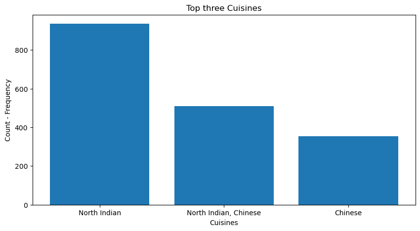

```python
plt.figure(figsize=(10,5))
values = value_counts['Cuisines']
labels = value_counts['count']
plt.bar(values,labels)
plt.title('Top three Cuisines')
plt.xlabel('Cuisines')
plt.ylabel("Count - Frequency")
plt.show()
```

- **Calculate the percentage of restaurants that serve each of the top cuisines**

```python
# adding new column 'Percentage' and calculate the percentage of restaurants that serve each of the top cuisines.
value_counts['Percentage'] = round((value_counts['count'] / len(restaurent_df))*100,2)
value_counts
```

|  | Cuisines | count | Percentage |
| --- | --- | --- | --- |
| 0 | North Indian | 936 | 9.80 |
| 1 | North Indian, Chinese | 511 | 5.35 |
| 2 | Chinese | 354 | 3.71 |

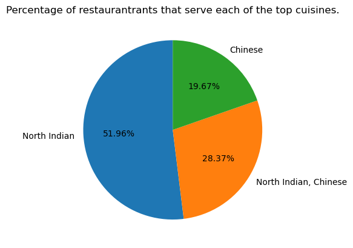

```python
plt.title('Percentage of restaurantrants that serve each of the top cuisines.')
plt.pie(value_counts['Percentage'],labels=value_counts['Cuisines'],autopct='%0.2f%%',startangle=90)
plt.show()
```

## **Task 2: City Analysis**

```python
city_restaurant_count = restaurent_df.groupby('City')['Restaurant Name'].count()

# Find the city with the highest number of restaurants
max_restaurant_city = city_restaurant_count.idxmax()
max_restaurant_count = city_restaurant_count.max()
print(f"{max_restaurant_city} has highest number of restaurants, the count of restaurants is {max_restaurant_count} restaurants.")
```

```
New Delhi has highest number of restaurants, the count of restaurants is 5473 restaurants.
```

- **Calculate the average rating for restaurants in each city.**

```python
avg_ratings_by_city = restaurent_df.groupby("City")["Aggregate rating"].mean().reset_index()
avg_ratings_by_city
```

|  | City | Aggregate rating |
| --- | --- | --- |
| 0 | Abu Dhabi | 4.300000 |
| 1 | Agra | 3.965000 |
| 2 | Ahmedabad | 4.161905 |
| 3 | Albany | 3.555000 |
| 4 | Allahabad | 3.395000 |
| ... | ... | ... |
| 136 | Weirton | 3.900000 |
| 137 | Wellington City | 4.250000 |
| 138 | Winchester Bay | 3.200000 |
| 139 | Yorkton | 3.300000 |
| 140 | ��stanbul | 4.292857 |

141 rows × 2 columns

- **Determine the city with the highest average rating**

```python
avg_ratings = restaurent_df.groupby("City")["Aggregate rating"].mean().reset_index()
avg_ratings = avg_ratings.sort_values(by="Aggregate rating",ascending=False)
print("City with the highest average rating")
avg_ratings.head(1)
```

```
City with the highest average rating
```

|  | City | Aggregate rating |
| --- | --- | --- |
| 56 | Inner City | 4.9 |

**Observations**

- City with the highest average rating
- **Inner** City with **4.9** as Avg Rating

## **Task 3 : Price Range Distribution**

- **Create a histogram or bar chart to visualize the distribution of price ranges among the restaurants.**

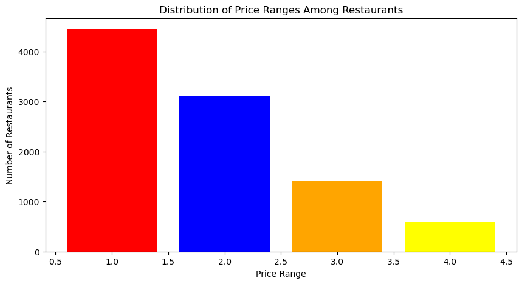

```python
price_counts = restaurent_df['Price range'].value_counts()
plt.figure(figsize=(10, 5))
plt.bar(price_counts.index, price_counts.values, color=['red', 'blue', 'orange','yellow'])
plt.xlabel('Price Range')
plt.ylabel('Number of Restaurants')
plt.title('Distribution of Price Ranges Among Restaurants')
plt.show()
```

**Observations**

- Distribution of price ranges among the restaurants
  - 1
  - 2
  - 3
  - 4
- **Calculate the percentage of restaurants in each price range category.**

```python
value_counts = restaurent_df["Price range"].value_counts().reset_index()

# Rename the columns
value_counts.columns = ['Price-Range', 'Count']
total_count = value_counts['Count'].sum()

value_counts['Percentage'] = round((value_counts['Count'] / total_count)*100,2)

# Print the result as a table
df = pd.DataFrame(value_counts)
df
```

|  | Price-Range | Count | Percentage |
| --- | --- | --- | --- |
| 0 | 1 | 4444 | 46.53 |
| 1 | 2 | 3113 | 32.59 |
| 2 | 3 | 1408 | 14.74 |
| 3 | 4 | 586 | 6.14 |

**Observations**

- Percentage of restaurants in each price range category.
  - Price Range :1 Percantage : 46.53%
  - Price Range :2 Percentage: 32.59%
  - Price Range :3 Percentage: 14.74%
  - Price Range: 4 Percentage: 6.14%

## **Task 4: Online Delivery**

- **Determine the percentage of restaurants that offer online delivery**

```python
total_restaurant_count =restaurent_df.shape[0]
online_restaurnat_count = restaurent_df[restaurent_df['Has Online delivery']=='Yes']
online_restaurant_count= online_restaurnat_count.shape[0]

# percentage of online order taken by the restaurants
percentage=round((online_restaurant_count/total_restaurant_count)*100,2)
print("percentage of online order taken by the restaurants")
print(percentage)
```

```
percentage of online order taken by the restaurants
25.66
```

**Observations**

- Percentage of restaurants that offer online delivery - 25.66%
- **Compare the average ratings of restaurants with and without online delivery.**

```python
# average rating of restaurant with and without online delivery
print("average rating of restaurant with and without online delivery")
restaurent_df.groupby('Has Online delivery')['Aggregate rating'].mean().round(2).reset_index()
```

```
average rating of restaurant with and without online delivery
```

|  | Has Online delivery | Aggregate rating |
| --- | --- | --- |
| 0 | No | 2.47 |
| 1 | Yes | 3.25 |

**Observations**

- average ratings of restaurants with and without online delivery
  - No - Online Delivery - Avg Rating - 2.47
  - Online Delivery - Avg Rating - 3.25